# Investigating titanic data

# the most interesting data to start data analyzing

## Introduction

**Purpose:** To performa data analysis on a sample Titanic dataset.

This dataset contains demographics and passenger information from 891 of the 2224 passengers and crew on board the Titanic. You can view a description of this dataset on the Kaggle website, where the data was obtained (https://www.kaggle.com/c/titanic/data).

# What factors made people more likely to survive?

1. **Were social-economic standing a factor in survival rate?**
2. **What is the relationship between a passenger's age and the probability that they survived?**
3. **Were children who travelled with higher Parch more likely to have survived?**
4. **Did women and children have preference to lifeboats and therefore survival (assuming there was no shortage of lifeboats)?**
5. **Did women with children have a better survival rate vs women without children (adults 18+)?**
6. **How did children with nannies fare in comparison to children with parents. Did the nanny "abandon" children to save his/her own life?**

# Data Description

(from https://www.kaggle.com/c/titanic)

### Variable Descriptions

```
survival        Survival
                (0 = No; 1 = Yes)
pclass          Passenger Class
                (1 = 1st; 2 = 2nd; 3 = 3rd)
name            Name
sex             Sex
age             Age
sibsp           Number of Siblings/Spouses Aboard
parch           Number of Parents/Children Aboard
ticket          Ticket Number
fare            Passenger Fare
cabin           Cabin
embarked        Port of Embarkation
                (C = Cherbourg; Q = Queenstown; S = Southampton)
```

**Special Notes:**

- Pclass is a proxy for socio-economic status (SES) 1st ~ Upper; 2nd ~ Middle; 3rd ~ Lower
- Age is in Years; Fractional if Age less than One (1) If the Age is Estimated, it is in the form xx.5

With respect to the family relation variables (i.e. sibsp and parch) some relations were ignored. The following are the definitions used for sibsp and parch.

- **Sibling:** Brother, Sister, Stepbrother, or Stepsister of Passenger Aboard Titanic
- **Spouse:** Husband or Wife of Passenger Aboard Titanic (Mistresses and Fiances Ignored)
- **Parent:** Mother or Father of Passenger Aboard Titanic
- **Child:** Son, Daughter, Stepson, or Stepdaughter of Passenger Aboard Titanic

```python
#import libraries
import numpy as np
import pandas as pd
import matplotlib as mpl
import matplotlib.pyplot as plt
%matplotlib inline
import seaborn as sns
sns.set(style="whitegrid", color_codes=True)
np.random.seed(sum(map(ord, "categorical")))

# Read in the dataset, create dataframe
titanic_data = pd.read_csv('titanic-data.csv')
```

```python
# Print the first few records to review data and format
titanic_data.head()
```

|  | PassengerId | Survived | Pclass | Name | Sex | Age | SibSp | Parch | Ticket | Fare | Cabin | Embarked |
| --- | --- | --- | --- | --- | --- | --- | --- | --- | --- | --- | --- | --- |
| 0 | 1 | 0 | 3 | Braund, Mr. Owen Harris | male | 22.0 | 1 | 0 | A/5 21171 | 7.2500 | NaN | S |
| 1 | 2 | 1 | 1 | Cumings, Mrs. John Bradley (Florence Briggs Th... | female | 38.0 | 1 | 0 | PC 17599 | 71.2833 | C85 | C |
| 2 | 3 | 1 | 3 | Heikkinen, Miss. Laina | female | 26.0 | 0 | 0 | STON/O2. 3101282 | 7.9250 | NaN | S |
| 3 | 4 | 1 | 1 | Futrelle, Mrs. Jacques Heath (Lily May Peel) | female | 35.0 | 1 | 0 | 113803 | 53.1000 | C123 | S |
| 4 | 5 | 0 | 3 | Allen, Mr. William Henry | male | 35.0 | 0 | 0 | 373450 | 8.0500 | NaN | S |

```python
#last few records
titanic_data.tail()
```

|  | PassengerId | Survived | Pclass | Name | Sex | Age | SibSp | Parch | Ticket | Fare | Cabin | Embarked |
| --- | --- | --- | --- | --- | --- | --- | --- | --- | --- | --- | --- | --- |
| 886 | 887 | 0 | 2 | Montvila, Rev. Juozas | male | 27.0 | 0 | 0 | 211536 | 13.00 | NaN | S |
| 887 | 888 | 1 | 1 | Graham, Miss. Margaret Edith | female | 19.0 | 0 | 0 | 112053 | 30.00 | B42 | S |
| 888 | 889 | 0 | 3 | Johnston, Miss. Catherine Helen "Carrie" | female | NaN | 1 | 2 | W./C. 6607 | 23.45 | NaN | S |
| 889 | 890 | 1 | 1 | Behr, Mr. Karl Howell | male | 26.0 | 0 | 0 | 111369 | 30.00 | C148 | C |
| 890 | 891 | 0 | 3 | Dooley, Mr. Patrick | male | 32.0 | 0 | 0 | 370376 | 7.75 | NaN | Q |

```python
print("\nTrain data info\n" + "-" * 40)
titanic_data.info()
```

```
Train data info
----------------------------------------
<class 'pandas.core.frame.DataFrame'>
RangeIndex: 891 entries, 0 to 890
Data columns (total 12 columns):
PassengerId    891 non-null int64
Survived       891 non-null int64
Pclass         891 non-null int64
Name           891 non-null object
Sex            891 non-null object
Age            714 non-null float64
SibSp          891 non-null int64
Parch          891 non-null int64
Ticket         891 non-null object
Fare           891 non-null float64
Cabin          204 non-null object
Embarked       889 non-null object
dtypes: float64(2), int64(5), object(5)
memory usage: 83.6+ KB
```

## Data Wrangling

I'll take a 3 step approach to data cleanup

1. Identify and remove any duplicate entries
2. Remove unnecessary columns
3. Fix missing and data format issues

#### Step 1 - Remove duplicate entries

```python
# Identify and remove duplicate entries
titanic_data_duplicates = titanic_data.duplicated()
print ('Number of duplicate entries is/are {}'.format(titanic_data_duplicates.sum()))
```

```
Number of duplicate entries is/are 0
```

It is noticeable that not every passenger had an assigned age. To investigate this further the pandas function `.count()` is used which is described as follows:

> Return Series with number of non-NA/null observations over requested axis.

```python
#count the non-NaN values in all coloums
titanic_data.count(axis='index', level=None, numeric_only=False)
```

```
PassengerId    891
Survived       891
Pclass         891
Name           891
Sex            891
Age            714
SibSp          891
Parch          891
Ticket         891
Fare           891
Cabin          204
Embarked       889
dtype: int64
```

It seems like the data for cabins is hardly available and some age values are also missing. For further analysis "Cabin" will be excluded completely and the lines where no age is available will be dropped. "Embarked" also has two missing values, which will be filled with the value "X" for "unknown", so these rows won't be dropped when calling `dropna()`.

#### Step 2 - Remove unnecessary columns

```python
#exclude "Cabin" and "Ticket", store in new dataframe "passengers"
passengers = titanic_data.drop('Cabin', axis=1, inplace=False)

#replace missing "Embarked" values with "X"
passengers['Embarked'].fillna("X", inplace=True)

#drop rows with missing values
passengers = passengers.dropna()
```

```python
#check passengers dataframe
print (passengers.count(axis='index', level=None, numeric_only=False))
passengers
```

```
PassengerId    714
Survived       714
Pclass         714
Name           714
Sex            714
Age            714
SibSp          714
Parch          714
Ticket         714
Fare           714
Embarked       714
dtype: int64
```

[output not shown]

714 rows × 11 columns

# Calculate number of missing values

```python
titanic_data.isnull().sum()
```

```
PassengerId      0
Survived         0
Pclass           0
Name             0
Sex              0
Age            177
SibSp            0
Parch            0
Ticket           0
Fare             0
Cabin          687
Embarked         2
dtype: int64
```

# Review some of the missing Age data

#### Step 3 - Fix any missing or data format issues

```python
missing_age_bool = pd.isnull(titanic_data['Age'])
titanic_data[missing_age_bool].head()
```

|  | PassengerId | Survived | Pclass | Name | Sex | Age | SibSp | Parch | Ticket | Fare | Cabin | Embarked |
| --- | --- | --- | --- | --- | --- | --- | --- | --- | --- | --- | --- | --- |
| 5 | 6 | 0 | 3 | Moran, Mr. James | male | NaN | 0 | 0 | 330877 | 8.4583 | NaN | Q |
| 17 | 18 | 1 | 2 | Williams, Mr. Charles Eugene | male | NaN | 0 | 0 | 244373 | 13.0000 | NaN | S |
| 19 | 20 | 1 | 3 | Masselmani, Mrs. Fatima | female | NaN | 0 | 0 | 2649 | 7.2250 | NaN | C |
| 26 | 27 | 0 | 3 | Emir, Mr. Farred Chehab | male | NaN | 0 | 0 | 2631 | 7.2250 | NaN | C |
| 28 | 29 | 1 | 3 | O'Dwyer, Miss. Ellen "Nellie" | female | NaN | 0 | 0 | 330959 | 7.8792 | NaN | Q |

```python
# Determine number of males and females with missing age values
missing_age_female = titanic_data[missing_age_bool]['Sex'] == 'female'
missing_age_male = titanic_data[missing_age_bool]['Sex'] == 'male'

print('Number for females and males with age missing are {} and {} respectively'.format(missing_age_female.sum(),
                                                                                        missing_age_male.sum()))
```

```
Number for females and males with age missing are 53 and 124 respectively
```

```python
# Taking a look at the datatypes
titanic_data.info()
```

```
<class 'pandas.core.frame.DataFrame'>
RangeIndex: 891 entries, 0 to 890
Data columns (total 12 columns):
PassengerId    891 non-null int64
Survived       891 non-null int64
Pclass         891 non-null int64
Name           891 non-null object
Sex            891 non-null object
Age            714 non-null float64
SibSp          891 non-null int64
Parch          891 non-null int64
Ticket         891 non-null object
Fare           891 non-null float64
Cabin          204 non-null object
Embarked       889 non-null object
dtypes: float64(2), int64(5), object(5)
memory usage: 83.6+ KB
```

- Age missing in male data: **124**
- Age missing in female data: **53**

The data is now clean and ready for exploration.

## Data Exploration and Visualization

```python
# Looking at some typical descriptive statistics
titanic_data.describe()
```

|  | PassengerId | Survived | Pclass | Age | SibSp | Parch | Fare |
| --- | --- | --- | --- | --- | --- | --- | --- |
| count | 891.000000 | 891.000000 | 891.000000 | 714.000000 | 891.000000 | 891.000000 | 891.000000 |
| mean | 446.000000 | 0.383838 | 2.308642 | 29.699118 | 0.523008 | 0.381594 | 32.204208 |
| std | 257.353842 | 0.486592 | 0.836071 | 14.526497 | 1.102743 | 0.806057 | 49.693429 |
| min | 1.000000 | 0.000000 | 1.000000 | 0.420000 | 0.000000 | 0.000000 | 0.000000 |
| 25% | 223.500000 | 0.000000 | 2.000000 | 20.125000 | 0.000000 | 0.000000 | 7.910400 |
| 50% | 446.000000 | 0.000000 | 3.000000 | 28.000000 | 0.000000 | 0.000000 | 14.454200 |
| 75% | 668.500000 | 1.000000 | 3.000000 | 38.000000 | 1.000000 | 0.000000 | 31.000000 |
| max | 891.000000 | 1.000000 | 3.000000 | 80.000000 | 8.000000 | 6.000000 | 512.329200 |

```python
# Age min at 0.42 looks a bit weird so give a closer look
titanic_data[titanic_data['Age'] < 1]
```

|  | PassengerId | Survived | Pclass | Name | Sex | Age | SibSp | Parch | Ticket | Fare | Cabin | Embarked |
| --- | --- | --- | --- | --- | --- | --- | --- | --- | --- | --- | --- | --- |
| 78 | 79 | 1 | 2 | Caldwell, Master. Alden Gates | male | 0.83 | 0 | 2 | 248738 | 29.0000 | NaN | S |
| 305 | 306 | 1 | 1 | Allison, Master. Hudson Trevor | male | 0.92 | 1 | 2 | 113781 | 151.5500 | C22 C26 | S |
| 469 | 470 | 1 | 3 | Baclini, Miss. Helene Barbara | female | 0.75 | 2 | 1 | 2666 | 19.2583 | NaN | C |
| 644 | 645 | 1 | 3 | Baclini, Miss. Eugenie | female | 0.75 | 2 | 1 | 2666 | 19.2583 | NaN | C |
| 755 | 756 | 1 | 2 | Hamalainen, Master. Viljo | male | 0.67 | 1 | 1 | 250649 | 14.5000 | NaN | S |
| 803 | 804 | 1 | 3 | Thomas, Master. Assad Alexander | male | 0.42 | 0 | 1 | 2625 | 8.5167 | NaN | C |
| 831 | 832 | 1 | 2 | Richards, Master. George Sibley | male | 0.83 | 1 | 1 | 29106 | 18.7500 | NaN | S |

```python
# Taking a look at some survival rates for babies
youngest_to_survive = titanic_data[titanic_data['Survived'] == True]['Age'].min()
youngest_to_die = titanic_data[titanic_data['Survived'] == False]['Age'].min()
oldest_to_survive = titanic_data[titanic_data['Survived'] == True]['Age'].max()
oldest_to_die = titanic_data[titanic_data['Survived'] == False]['Age'].max()

print ('Youngest to survive: {} \nYoungest to die: {} \nOldest to survive: {} \nOldest to die: {}'.format(
youngest_to_survive, youngest_to_die, oldest_to_survive, oldest_to_die))
```

```
Youngest to survive: 0.42
Youngest to die: 1.0
Oldest to survive: 80.0
Oldest to die: 74.0
```

Data description states that Age can be fractional - *Age is in Years; Fractional if Age less than One (1) If the Age is Estimated, it is in the form xx.5* - Therefore, 0.42 appears to be expected and normal data

**Note:** An interesting note is that all "new borns" survived. Potential **Q6** - At what age did children's survival rate match that of adults, if ever.

Other notable stats

- Oldest to survive: **80**
- Oldest to die: **74**
- Youngest to survive: **< 1 (0.42)**
- Youngest to die: **1**

## Question 1

Were social-economic standing a factor in survival rate?

```python
#define colors
c_female = '#CB5D5D'
c_male = '#6B8EB3'
c_green = '#A6B579'
c_darkgray = '#4A4A4A'
c_gold = '#FFD700'
c_silver = '#C0C0C0'
c_bronze = '#cd7f32'
```

```python
# Returns survival rate/percentage of sex and class
def survival_rate(pclass, sex):
    """
    Args:
        pclass: class value 1,2 or 3
        sex: male or female
    Returns:
        survival rate as percentage.
    """
    grouped_by_total = titanic_data.groupby(['Pclass', 'Sex']).size()[pclass,sex].astype('float')
    grouped_by_survived_sex = \
        titanic_data.groupby(['Pclass','Survived','Sex']).size()[pclass,1,sex].astype('float')
    survived_sex_pct = (grouped_by_survived_sex / grouped_by_total * 100).round(2)

    return survived_sex_pct
```

```python
# Get the actual numbers grouped by class, suvival and sex
groupedby_class_survived_size = titanic_data.groupby(['Pclass','Survived','Sex']).size()

# Print - Grouped by class, survival and sex
print ("groupedby_class_survived_size")
print ('Class 1 - female survival rate:{} '.format(survival_rate(1,'female')))
print ('Class 1 - male survival rate:{} '.format(survival_rate(1,'male')))
print ('-----')
print ('Class 2 - female survival rate:{} '.format(survival_rate(2,'female')))
print ('Class 2 - male survival rate:{} '.format(survival_rate(2,'male')))
print ('-----')
print ('Class 3 - female survival rate:{} '.format(survival_rate(3,'female')))
print ('Class 3 - male survival rate:{} '.format(survival_rate(3,'male')))
```

```
groupedby_class_survived_size
Class 1 - female survival rate:96.81
Class 1 - male survival rate:36.89
-----
Class 2 - female survival rate:92.11
Class 2 - male survival rate:15.74
-----
Class 3 - female survival rate:50.0
Class 3 - male survival rate:13.54
```

```python
# Group data by passengers' socioeconomic class
q1 = titanic_data.groupby('Pclass')
# Number of passengers in each socioeconomic class
pclass_count = q1['Pclass'].count()
print(pclass_count)
# Number of passengers who survived from each socioeconomic class
pclass_survived = q1['Survived'].sum()
print(pclass_survived)
```

```
Pclass
1    216
2    184
3    491
Name: Pclass, dtype: int64
Pclass
1    136
2     87
3    119
Name: Survived, dtype: int64
```

```python
# Calculate passenger survival rate for each socioeconomic class
pclass_survived_rate = pclass_survived / pclass_count # Use of vectorized operations
print(pclass_survived_rate)
```

```
Pclass
1    0.629630
2    0.472826
3    0.242363
dtype: float64
```

## Conclusion

From observation, it seems as though there is a positive correlation between a passenger's socioeconomic class and their rate of survival.

## Exploration

### Travel Class

Starting with the class the passengers traveled by:

1st = Upper  
2nd = Middle  
3rd = Lower

```python
#grouping the data by class and calculating the mean survival
survival_pclass = passengers.groupby('Pclass')['Survived'].mean()*100 #multiply times 100 for percent
survival_pclass
```

```
Pclass
1    65.591398
2    47.976879
3    23.943662
Name: Survived, dtype: float64
```

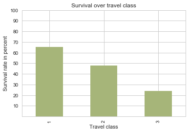

```python
%pylab inline

#plot bar graph
ax = survival_pclass.plot(
    title='Survival over travel class',
    kind='bar',
    yticks=[10,20,30,40,50,60,70,80,90,100],
    color=c_green)

#set labels for axis
ax.set_xlabel("Travel class")
ax.set_ylabel("Survival rate in percent")
```

In this data set 65.59% of the first class passengers survived the catastrophe, while in the second class less than half - 47.98%, to be exact - passengers could be rescued. In the third class only 23.94% made it out alive.

This shows that a **better travel class is positively correlated with survial**.

### Sex

```python
#calculating survival rates per sex in percent
survival_sex = passengers.groupby('Sex')['Survived'].mean()*100 #multiply times 100 for percent
survival_sex
```

```
Sex
female    75.478927
male      20.529801
Name: Survived, dtype: float64
```

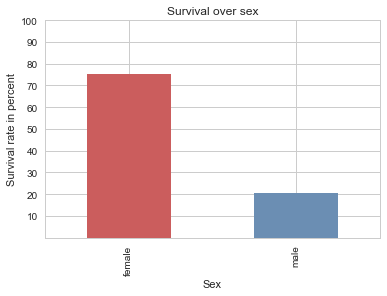

```python
#plot bar graph
ax = survival_sex.plot(
    title='Survival over sex',
    kind='bar',
    yticks=[10,20,30,40,50,60,70,80,90,100],
    color=[c_female, c_male]
)

#set labels for axis
ax.set_xlabel("Sex")
ax.set_ylabel("Survival rate in percent")
```

Grouping the data by sex and calculating the mean survival rate has shown that 75.48% of all women survived, while only 20.53% of all men did.

### Age

To investigate the influence of age, the overall age distribution is explored first.

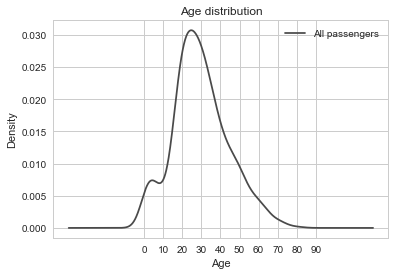

```python
#plot graph
ax = passengers.Age.plot(
    title='Age distribution',
    kind='kde',
    xticks=[0,10,20,30,40,50,60,70,80,90],
    color=c_darkgray,
    legend=True,
    label='All passengers')

#set x-axis label
ax.set_xlabel("Age")
```

Now the same plot will be split in two curves according to survival.

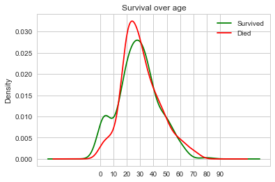

```python
#plot "survived" curve
passengers.Age[passengers.Survived == 1].plot(
    title='Survival over age',
    kind='kde',
    xticks=[0,10,20,30,40,50,60,70,80,90],
    color='green',
    legend=True,
    label='Survived')

#plot "died" curve
passengers.Age[passengers.Survived == 0].plot(
    kind='kde',
    xticks=[0,10,20,30,40,50,60,70,80,90],
    color='red',
    legend=True,
    label='Died')
```

This plot suggests that children had a higher chance of survival. To investigate this in more detail I will take a look at the survialrate in certain age intervals.

- Babies: 0-1 years
- Children: 1-12 years
- Teenager: 13-19 years
- Young adult: 20-29 years
- Adult: >= 30 years

```python
#plot bar graph
#include_lowest: Whether the first interval should be left-inclusive or not.
passengers['Age_category'] = pd.cut(
    passengers.Age,
    [0,1,12,19,29,100],
    labels=["baby","child","teen","young adult","adult"],
    include_lowest=True)

#calculate survaval by age category
survival_ageCategory = passengers.groupby('Age_category')['Survived'].mean()*100 #multiply times 100 for percent
survival_ageCategory
```

```
Age_category
baby           85.714286
child          50.909091
teen           41.052632
young adult    35.000000
adult          40.606061
Name: Survived, dtype: float64
```

[figure not shown]

```python
#plot bar graph
ax = survival_ageCategory.plot(
    title='Survival over age category',
    kind='bar',
    yticks=[10,20,30,40,50,60,70,80,90,100],
    color=c_darkgray)

#set labels for axis
ax.set_xlabel("Travel class")
ax.set_ylabel("Survival rate in percent")
```

85.71% of the babies (0 - 1 years) included in this dataset survived.  
50.91% of the children (1 - 12 years) included in this dataset survived.  
41.05% of the teenagers (13 - 19 years) included in this dataset survived.  
35.00% of the young adults (20 - 29 years) included in this dataset survived.  
40.61% of the adults (30 years and above) included in this dataset survived.  
**Especially babys, but also children had better survival chances according to this data.**

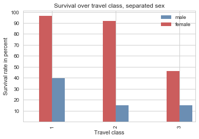

```python
#grouping, multiply times 100 for percent
survival_sex_class = passengers.groupby(['Sex','Pclass'])['Survived'].mean()*100


#plot bar graph men
survival_sex_class.loc['male'].plot(
    kind='bar',
    yticks=[10,20,30,40,50,60,70,80,90,100],
    color=c_male,
    position = 0,
    width=0.2,
    legend=True,
    label='male',)

#plot bar graph women
ax = survival_sex_class.loc['female'].plot(
    title='Survival over travel class, separated sex',
    kind='bar',
    yticks=[10,20,30,40,50,60,70,80,90,100],
    color=c_female,
    position = 1,
    width=0.2,
    legend=True,
    label='female',)


#set labels for axis
ax.set_xlabel("Travel class")
ax.set_ylabel("Survival rate in percent")
```

**The data suggests that especially women with travel class 1 and 2 were likely to survive. Men in the first class seem to be twice as likely to have survived the catastrophe than those in the second and third class. But even this seemingly high chance of survival (of men in the first class) is lower than women had in the third class.**

## Q2 What is the relationship between a passenger's age and the probability that they survived?

```python
# Clean data
data_survived_age = titanic_data[['Survived', 'Age']].dropna().mean()
```

```python
# Calculate mean age for those who survived and those who didn't
q2 = titanic_data.groupby('Survived')
q2['Age'].mean()
```

```
Survived
0    30.626179
1    28.343690
Name: Age, dtype: float64
```

```python
q2.head()
```

|  | PassengerId | Survived | Pclass | Name | Sex | Age | SibSp | Parch | Ticket | Fare | Cabin | Embarked |
| --- | --- | --- | --- | --- | --- | --- | --- | --- | --- | --- | --- | --- |
| 0 | 1 | 0 | 3 | Braund, Mr. Owen Harris | male | 22.0 | 1 | 0 | A/5 21171 | 7.2500 | NaN | S |
| 1 | 2 | 1 | 1 | Cumings, Mrs. John Bradley (Florence Briggs Th... | female | 38.0 | 1 | 0 | PC 17599 | 71.2833 | C85 | C |
| 2 | 3 | 1 | 3 | Heikkinen, Miss. Laina | female | 26.0 | 0 | 0 | STON/O2. 3101282 | 7.9250 | NaN | S |
| 3 | 4 | 1 | 1 | Futrelle, Mrs. Jacques Heath (Lily May Peel) | female | 35.0 | 1 | 0 | 113803 | 53.1000 | C123 | S |
| 4 | 5 | 0 | 3 | Allen, Mr. William Henry | male | 35.0 | 0 | 0 | 373450 | 8.0500 | NaN | S |
| 5 | 6 | 0 | 3 | Moran, Mr. James | male | NaN | 0 | 0 | 330877 | 8.4583 | NaN | Q |
| 6 | 7 | 0 | 1 | McCarthy, Mr. Timothy J | male | 54.0 | 0 | 0 | 17463 | 51.8625 | E46 | S |
| 7 | 8 | 0 | 3 | Palsson, Master. Gosta Leonard | male | 2.0 | 3 | 1 | 349909 | 21.0750 | NaN | S |
| 8 | 9 | 1 | 3 | Johnson, Mrs. Oscar W (Elisabeth Vilhelmina Berg) | female | 27.0 | 0 | 2 | 347742 | 11.1333 | NaN | S |
| 9 | 10 | 1 | 2 | Nasser, Mrs. Nicholas (Adele Achem) | female | 14.0 | 1 | 0 | 237736 | 30.0708 | NaN | C |

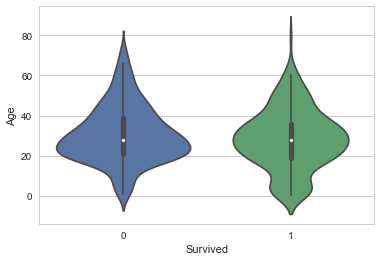

```python
#Scatterplot to get an idea of the data
sns.violinplot(titanic_data['Survived'], titanic_data['Age'])
```

## Q3 Were children who travelled with higher Parch more likely to have survived?

What factors made children more likely to survive? Specifically, were children who travelled with their families more likely to have survived than children who travelled with only nannies (ParCh = 0), since their nannies would have less vested interest in them than their parents?

1. Select rows where Age <= 18
2. Select Age, Survived and ParentChild columns
3. Groupby ParentChild

```python
# Select Age, ParentChild and Survived columns
q3 = data_survived_age = titanic_data[['Age', 'Parch', 'Survived']].dropna()
```

```python
q3.head()
```

|  | Age | Parch | Survived |
| --- | --- | --- | --- |
| 0 | 22.0 | 0 | 0 |
| 1 | 38.0 | 0 | 1 |
| 2 | 26.0 | 0 | 1 |
| 3 | 35.0 | 0 | 1 |
| 4 | 35.0 | 0 | 0 |

```python
# Filter Age <= 18
q3_filtered = q3[q3['Age'] <= 18]
```

```python
q3_parch = q3_filtered.groupby('Parch')
```

```python
q3_parch.mean()
```

| Parch | Age | Survived |
| --- | --- | --- |
| 0 | 16.250000 | 0.400000 |
| 1 | 7.294286 | 0.591837 |
| 2 | 7.788462 | 0.538462 |
| 3 | 16.000000 | 0.000000 |

```python
q3_parch['Survived'].count()
```

```
Parch
0    50
1    49
2    39
3     1
Name: Survived, dtype: int64
```

```python
q3_parch.describe()
```

| Parch |  | Age | Survived |
| --- | --- | --- | --- |
| 0 | count | 50.000000 | 50.000000 |
|  | mean | 16.250000 | 0.400000 |
|  | std | 2.334851 | 0.494872 |
|  | min | 5.000000 | 0.000000 |
|  | 25% | 16.000000 | 0.000000 |
|  | 50% | 17.000000 | 0.000000 |
|  | 75% | 18.000000 | 1.000000 |
|  | max | 18.000000 | 1.000000 |
| 1 | count | 49.000000 | 49.000000 |
|  | mean | 7.294286 | 0.591837 |
|  | std | 6.217106 | 0.496587 |
|  | min | 0.420000 | 0.000000 |
|  | 25% | 2.000000 | 0.000000 |
|  | 50% | 4.000000 | 1.000000 |
|  | 75% | 14.000000 | 1.000000 |
|  | max | 18.000000 | 1.000000 |
| 2 | count | 39.000000 | 39.000000 |
|  | mean | 7.788462 | 0.538462 |
|  | std | 5.571993 | 0.505035 |
|  | min | 0.830000 | 0.000000 |
|  | 25% | 3.000000 | 0.000000 |
|  | 50% | 8.000000 | 1.000000 |
|  | 75% | 11.000000 | 1.000000 |
|  | max | 18.000000 | 1.000000 |
| 3 | count | 1.000000 | 1.000000 |
|  | mean | 16.000000 | 0.000000 |
|  | std | NaN | NaN |
|  | min | 16.000000 | 0.000000 |
|  | 25% | 16.000000 | 0.000000 |
|  | 50% | 16.000000 | 0.000000 |
|  | 75% | 16.000000 | 0.000000 |
|  | max | 16.000000 | 0.000000 |

Children who travelled alone or with a nanny were older on average: they had a mean age of 16.25 with std 2.33. There was only one child (16 years old) who travelled with Parch = 3, so we cannot draw conclusions specifically about families where Parch >=3 because n = 1 is small.

```python
# Review some of the missing Age data
missing_age_bool = pd.isnull(titanic_data['Age'])
titanic_data[missing_age_bool].head()
# Determine number of males and females with missing age values
missing_age_female = titanic_data[missing_age_bool]['Sex'] == 'female'
missing_age_male = titanic_data[missing_age_bool]['Sex'] == 'male'
```

```
Number of men and woman with age missing are 53 and 124 respectively
Total number of survivors 123
\Total number of non survivors 60
\Mean age of survivors 33.0
\Mean age of non survivors 41.0
\Oldest to survive 80.0
\Oldest to not survive 74.0
```

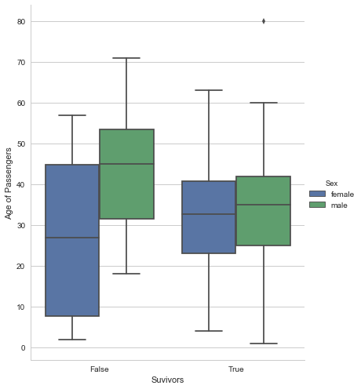

```python
# Let us first identify and get rid of records with missing Age
print ('Number of men and woman with age missing are {} and {} respectively'.format(missing_age_female.sum(),missing_age_male.sum()))

# Drop the NaN values. Calculations will be okay with them (seen as zero) but will throw off averages and counts
titanic_data_age_cleaned = titanic_data.dropna()

# Find total count of survivors and those who didn't
number_survived = titanic_data_age_cleaned[titanic_data_age_cleaned['Survived'] == True]['Survived'].count()
number_died = titanic_data_age_cleaned[titanic_data_age_cleaned['Survived'] == False]['Survived'].count()

# Find average of survivors and those who didn't
mean_age_survived = titanic_data_age_cleaned[titanic_data_age_cleaned['Survived'] == True]['Age'].mean()
mean_age_died = titanic_data_age_cleaned[titanic_data_age_cleaned['Survived'] == False]['Age'].mean()

# Display a few raw totals
print ("Total number of survivors {} \n\Total number of non survivors {} \n\Mean age of survivors {} \n\Mean age of non survivors {} \n\Oldest to survive {} \n\Oldest to not survive {}".format(number_survived, number_died, np.round(mean_age_survived), np.round(mean_age_died), oldest_to_survive, oldest_to_die))

# Graph - Age of passengers across sex of those who survived
g = sns.factorplot(x="Survived", y="Age", hue='Sex', data=titanic_data_age_cleaned, kind="box", size=7, aspect=.8)

# Fix up the labels
(g.set_axis_labels('Suvivors', 'Age of Passengers')
    .set_xticklabels(["False", "True"])
)
```

## Question 4

Did women and children have preference to lifeboats and therefore survival (assuming there was no shortage of lifeboats)?

**Assumption:** With "child" not classified in the data, I'll need to assume a cutoff point. Therefore, I'll be using today's standard of under 18 as those to be considered as a child vs adult

```
Category  Survived
Child     0            2
          1           17
Man       0           54
          1           33
Woman     0            4
          1           73
dtype: int64
```

[figure not shown]

```python
# Create Cateogry column and categorize people
titanic_data_age_cleaned.loc[
    ( (titanic_data_age_cleaned['Sex'] == 'female') &
    (titanic_data_age_cleaned['Age'] >= 18) ),
    'Category'] = 'Woman'

titanic_data_age_cleaned.loc[
    ( (titanic_data_age_cleaned['Sex'] == 'male') &
    (titanic_data_age_cleaned['Age'] >= 18) ),
    'Category'] = 'Man'

titanic_data_age_cleaned.loc[
    (titanic_data_age_cleaned['Age'] < 18),
    'Category'] = 'Child'

# Get the totals grouped by Men, Women and Children, and by survival
print (titanic_data_age_cleaned.groupby(['Category','Survived']).size())

# Graph - Compare survival count between Men, Women and Children
g = sns.factorplot('Survived', col='Category', data=titanic_data_age_cleaned, kind='count', size=7, aspect=.8)

# Fix up the labels
(g.set_axis_labels('Suvivors', 'No. of Passengers')
    .set_xticklabels(['False', 'True'])
)

titles = ['Men', 'Women', 'Children']
for ax, title in zip(g.axes.flat, titles):
    ax.set_title(title)
```

## Question 5

```python
# Determine number of woman that are not parents
titanic_data_woman_parents = titanic_data_age_cleaned.loc[
    (titanic_data_age_cleaned['Category'] == 'Woman') &
    (titanic_data_age_cleaned['Parch'] > 0)]

# Determine number of woman over 20 that are not parents
titanic_data_woman_parents_maybe = titanic_data_age_cleaned.loc[
    (titanic_data_age_cleaned['Category'] == 'Woman') &
    (titanic_data_age_cleaned['Parch'] > 0) &
    (titanic_data_age_cleaned['Age'] > 20)]
```

```python
titanic_data_woman_parents.head()
```

|  | PassengerId | Survived | Pclass | Name | Sex | Age | SibSp | Parch | Ticket | Fare | Cabin | Embarked | Category |
| --- | --- | --- | --- | --- | --- | --- | --- | --- | --- | --- | --- | --- | --- |
| 88 | 89 | 1 | 1 | Fortune, Miss. Mabel Helen | female | 23.0 | 3 | 2 | 19950 | 263.0000 | C23 C25 C27 | S | Woman |
| 136 | 137 | 1 | 1 | Newsom, Miss. Helen Monypeny | female | 19.0 | 0 | 2 | 11752 | 26.2833 | D47 | S | Woman |
| 251 | 252 | 0 | 3 | Strom, Mrs. Wilhelm (Elna Matilda Persson) | female | 29.0 | 1 | 1 | 347054 | 10.4625 | G6 | S | Woman |
| 268 | 269 | 1 | 1 | Graham, Mrs. William Thompson (Edith Junkins) | female | 58.0 | 0 | 1 | PC 17582 | 153.4625 | C125 | S | Woman |
| 299 | 300 | 1 | 1 | Baxter, Mrs. James (Helene DeLaudeniere Chaput) | female | 50.0 | 0 | 1 | PC 17558 | 247.5208 | B58 B60 | C | Woman |

## Question 6

How did children with nannies fare in comparison to children with parents. Did the nanny "abandon" children to save his/her own life?

- Need to review list for children with no parents. These will be children with nannies as stated in the data description
- Compare "normal" survival rate of children with parents against children with nannies

Assumptions:

1. If you're classified as a 'Child' (under 18) and have Parch > 0, then the value is associated to your Parents, eventhough it is possible to be under 18 and also have children
2. Classifying people as 'Child' represented by those under 18 years old is applying today's standards to the 1900 century

```python
# Separate out children with parents from those with nannies
titanic_data_children_nannies = titanic_data_age_cleaned.loc[
    (titanic_data_age_cleaned['Category'] == 'Child') &
    (titanic_data_age_cleaned['Parch'] == 0)]

titanic_data_children_parents = titanic_data_age_cleaned.loc[
    (titanic_data_age_cleaned['Category'] == 'Child') &
    (titanic_data_age_cleaned['Parch'] > 0)]
```

```python
# Determine children with nannies who survived and who did not
survived_children_nannies = titanic_data_children_nannies.Survived.sum()
total_children_nannies = titanic_data_children_nannies.Survived.count()
pct_survived_nannies = ((float(survived_children_nannies)/total_children_nannies)*100)
pct_survived_nannies = np.round(pct_survived_nannies,2)
survived_children_nannies_avg_age = np.round(titanic_data_children_nannies.Age.mean())

# Display results
print ('Total number of children with nannies: {}\n\
Children with nannies who survived: {}\n\
Children with nannies who did not survive: {}\n\
Percentage of children who survived: {}%\n\
Average age of surviving children: {}'\
.format(total_children_nannies, survived_children_nannies,
        total_children_nannies-survived_children_nannies, pct_survived_nannies, survived_children_nannies_avg_age))

# Verify counts (looked a bit too evenly divided)
titanic_data_children_nannies.loc[titanic_data_children_nannies['Survived'] == 1]
```

```
Total number of children with nannies: 3
Children with nannies who survived: 3
Children with nannies who did not survive: 0
Percentage of children who survived: 100.0%
Average age of surviving children: 17.0
```

|  | PassengerId | Survived | Pclass | Name | Sex | Age | SibSp | Parch | Ticket | Fare | Cabin | Embarked | Category |
| --- | --- | --- | --- | --- | --- | --- | --- | --- | --- | --- | --- | --- | --- |
| 307 | 308 | 1 | 1 | Penasco y Castellana, Mrs. Victor de Satode (M... | female | 17.0 | 1 | 0 | PC 17758 | 108.9 | C65 | C | Child |
| 504 | 505 | 1 | 1 | Maioni, Miss. Roberta | female | 16.0 | 0 | 0 | 110152 | 86.5 | B79 | S | Child |
| 781 | 782 | 1 | 1 | Dick, Mrs. Albert Adrian (Vera Gillespie) | female | 17.0 | 1 | 0 | 17474 | 57.0 | B20 | S | Child |

```python
# Determine children with parents who survived and who did not
survived_children_parents = titanic_data_children_parents.Survived.sum()
total_children_parents = titanic_data_children_parents.Survived.count()
pct_survived_parents = ((float(survived_children_parents)/total_children_parents)*100)
pct_survived_parents = np.round(pct_survived_parents,2)
survived_children_parents_avg_age = np.round(titanic_data_children_parents.Age.mean())

# Display results
print ('Total number of children with parents: {}\n\
Children with parents who survived: {}\n\
Children with parents who did not survive: {}\n\
Percentage of children who survived: {}%\n\
Average age of surviving children: {}'\
.format(total_children_parents, survived_children_parents,
        total_children_parents-survived_children_parents, pct_survived_parents,survived_children_parents_avg_age))
```

```
Total number of children with parents: 16
Children with parents who survived: 14
Children with parents who did not survive: 2
Percentage of children who survived: 87.5%
Average age of surviving children: 7.0
```

## Conclusion

**Issues:**

- A portion of men and women did not have Age data and were removed from calculations which could have skewed some numbers
- The category of 'children' was assumed to be anyone under the age of 18, using today's North American standard for adulthood which was certainly not the case in the 1900s

### What factors made people more likely to survive?

All investigated independent variables ("Pclass", "Sex", "Age") have a correlation with the dependent variable of survival.

#### Pclass (Travel class):

- A **better travel** class is positively correlated with survival.